# Mid-Term: Math 425

```r
library(car)
library(tidyverse)
library(mosaic)
library(pander)
library(ggplot2)
library(readr)
library(stringr)
library(DT)
library(pander)
library(gridExtra)
library(MASS)
library(ResourceSelection)
```

#### Question 1 {done/WRONG}

#### Question 2 {done}

Open the `RailTrail` data set in R from library(mosaic).

Perform an appropriate analysis that would allow you to predict the `average volume of users` on the trail by knowing the `cloud cover measurement` for a given day.

Estimate the average volume of users on the trail for days with a cloud cover measurement of 4.

```r
#?RailTrail
RailTrail.lm <- lm(volume ~ cloudcover, data = RailTrail)
RailTrail.lm.co <- RailTrail.lm$coefficients
pander(summary(RailTrail.lm))
```

|  | Estimate | Std. Error | t value | Pr(>\|t\|) |
| --- | --- | --- | --- | --- |
| **(Intercept)** | 461.3 | 25.9 | 17.81 | 6.347e-31 |
| **cloudcover** | -14.8 | 3.905 | -3.79 | 0.0002757 |

Fitting linear model: volume ~ cloudcover

| Observations | Residual Std. Error | $R^2$ | Adjusted $R^2$ |
| --- | --- | --- | --- |
| 90 | 118.9 | 0.1403 | 0.1305 |

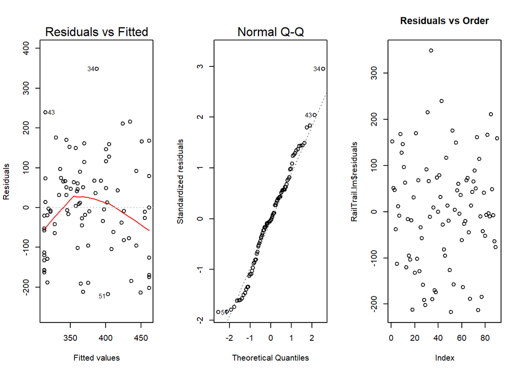

```r
# Check Assumptions
par(mfrow=c(1,3))
plot(RailTrail.lm, which=1:2)
plot(RailTrail.lm$residuals, main = "Residuals vs Order")
```

```r
# plot(RailTrail.lm, which = 1)
# qqPlot(RailTrail.lm$residuals, main = "Q-Q Plot of Residuals", id = FALSE)
```

Everything checks out

```r
predict(RailTrail.lm, data.frame(cloudcover=4), interval="prediction")
```

```
##        fit      lwr      upr
## 1 402.1336 164.2159 640.0513
```

#### Question 3 {done}

I am going with answer two because there are more data points to argue for more evidence of non-linearity.

#### Question 4 {done}

Using the notation we have learned in our course this semester for the regression model, which of the following statements contains an error?

We don’t use betas when measuring for the average y-value.

#### Question 5 {HELP/WRONG}

I’m not sure. I just looked at the graphs online and compared numbers.I don’t think the numbers can be above 100

```r
(7.1 + 13 + 7.4 + 4.1 + 2.7)^2
```

```
## [1] 1176.49
```

```r
19
```

```
## [1] 19
```

#### Question 6 {done}

Report the value of the p-value for their test.

```r
# ?cars
# View(cars)
cars.lm <- lm(dist ~ speed, data = cars)
summary(cars.lm)
```

```
##
## Call:
## lm(formula = dist ~ speed, data = cars)
##
## Residuals:
##     Min      1Q  Median      3Q     Max
## -29.069  -9.525  -2.272   9.215  43.201
##
## Coefficients:
##             Estimate Std. Error t value Pr(>|t|)
## (Intercept) -17.5791     6.7584  -2.601   0.0123 *
## speed         3.9324     0.4155   9.464 1.49e-12 ***
## ---
## Signif. codes:  0 '***' 0.001 '**' 0.01 '*' 0.05 '.' 0.1 ' ' 1
##
## Residual standard error: 15.38 on 48 degrees of freedom
## Multiple R-squared:  0.6511, Adjusted R-squared:  0.6438
## F-statistic: 89.57 on 1 and 48 DF,  p-value: 1.49e-12
```

```r
#T-stat math formula: (Estimate (b_0 or b_1) - hypothesis number)/std.Error_{b_0 or b_1}
# (-17.579 - 0)/16.7006 # Interc t-stat
(3.9324 - 3.8)/0.4155 # Slope t-stat
```

```
## [1] 0.3186522
```

```r
# b_0.lm <- (45.7966 - 0)/16.7006
b_1.cars <- (3.9324 - 3.8)/0.4155
#P-value is hard to calculate use this: pt(-abs(tvalue), degrees of freedom)
# pt(-abs(b_0.lm), 134)*2 # Interc p-value
pt(-abs(b_1.cars), 48)*2 # Slope p-value
```

```
## [1] 0.7513727
```

#### Question 7 {done/WRONG}

The $R^2$ is at 0.56 meaning that the points are only half the time near the regression line. So this will not be the best fit. The p-values are significant but some sort of transformation will need to take place for the regression model to matter.

#### Question 8

Use the mtcars data set in R to perform an appropriate transformation regression of mpg against wt.

Use your transformation regression to predict the gas mileage (mpg) of a vehicle that has a weight of 4,000 lbs.

```r
# ?mtcars
# View(mtcars)

mtcars.lm <- lm(mpg ~ wt, data = mtcars)
mtcars.lm.co <- mtcars.lm$coefficients
summary(mtcars.lm)
```

```
##
## Call:
## lm(formula = mpg ~ wt, data = mtcars)
##
## Residuals:
##     Min      1Q  Median      3Q     Max
## -4.5432 -2.3647 -0.1252  1.4096  6.8727
##
## Coefficients:
##             Estimate Std. Error t value Pr(>|t|)
## (Intercept)  37.2851     1.8776  19.858  < 2e-16 ***
## wt           -5.3445     0.5591  -9.559 1.29e-10 ***
## ---
## Signif. codes:  0 '***' 0.001 '**' 0.01 '*' 0.05 '.' 0.1 ' ' 1
##
## Residual standard error: 3.046 on 30 degrees of freedom
## Multiple R-squared:  0.7528, Adjusted R-squared:  0.7446
## F-statistic: 91.38 on 1 and 30 DF,  p-value: 1.294e-10
```

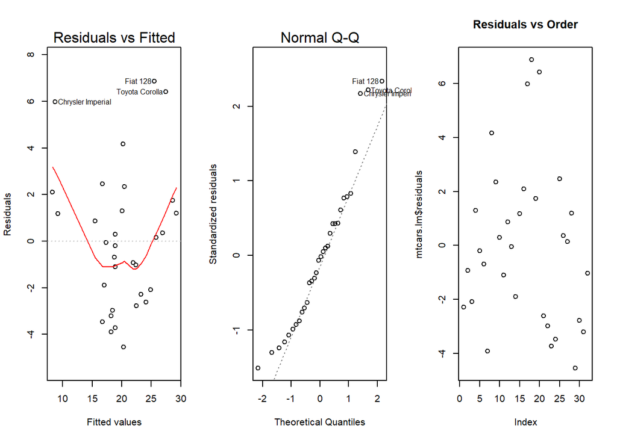

```r
# Check Assumptions
par(mfrow=c(1,3))
plot(mtcars.lm, which=1:2)
plot(mtcars.lm$residuals, main = "Residuals vs Order")
```

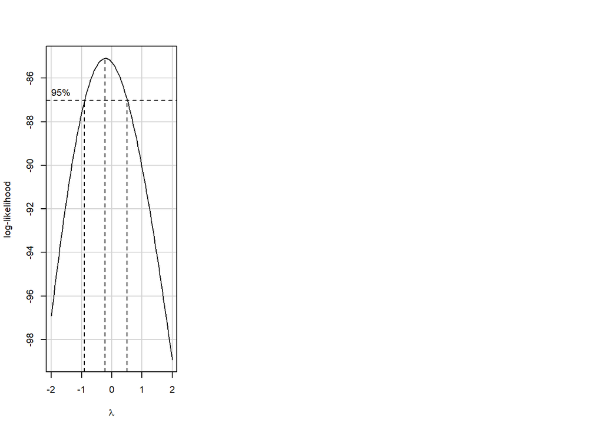

```r
# plot(mtcars.lm, which = 1)
# qqPlot(mtcars.lm$residuals, main = "Q-Q Plot of Residuals", id = FALSE)
boxCox(mtcars.lm)
mtcars.lm.t <- lm(mpg^.25 ~ wt, data = mtcars)
```

```r
predict(mtcars.lm.t, data.frame(wt=4), interval="prediction") # Do I sqrt this?
```

```
##        fit    lwr      upr
## 1 1.989058 1.8367 2.141415
```

```r
# exp(predict(mtcars.lm.t, data.frame(wt=4), interval="prediction")) # I logged the mt.lm.t
```

#### Question 9 {done}

```r
# ?cars
cars.lm9.t <- lm(sqrt(dist) ~ speed, data = cars)
cars.lm9.t.co <- cars.lm9.t$coefficients
summary(mtcars.lm)
```

```
##
## Call:
## lm(formula = mpg ~ wt, data = mtcars)
##
## Residuals:
##     Min      1Q  Median      3Q     Max
## -4.5432 -2.3647 -0.1252  1.4096  6.8727
##
## Coefficients:
##             Estimate Std. Error t value Pr(>|t|)
## (Intercept)  37.2851     1.8776  19.858  < 2e-16 ***
## wt           -5.3445     0.5591  -9.559 1.29e-10 ***
## ---
## Signif. codes:  0 '***' 0.001 '**' 0.01 '*' 0.05 '.' 0.1 ' ' 1
##
## Residual standard error: 3.046 on 30 degrees of freedom
## Multiple R-squared:  0.7528, Adjusted R-squared:  0.7446
## F-statistic: 91.38 on 1 and 30 DF,  p-value: 1.294e-10
```

```r
predict(cars.lm9.t, data.frame(speed=20), interval="prediction")^2
```

```
##        fit      lwr      upr
## 1 59.68027 29.91906 99.61575
```

#### Question 10 {done}

```r
# ?airquality
airqual.lm <- lm(Temp ~ Wind, data = airquality)
airqual.lm.co <- airqual.lm$coefficients
```

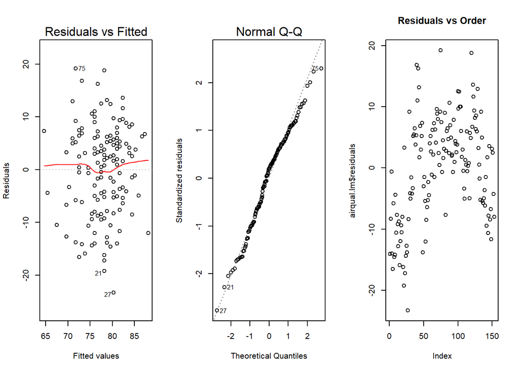

```r
# Check Assumptions
par(mfrow=c(1,3))
plot(airqual.lm, which=1:2)
plot(airqual.lm$residuals, main = "Residuals vs Order")
```

```r
# plot(airqual.lm, which = 1)
# qqPlot(airqual.lm$residuals, main = "Q-Q Plot of Residuals", id = FALSE)
```

#### Question 11 {done}

Suppose you are asked to help decide how wide (in centimeters) kid’s shoes should be for girls with foot lengths of 25 centimeters. Suppose further you are provided with the `KidsFeet` dataset found in library(mosaic). Perform a regression that would help provide an answer to this question.

Select the interval below that, according to your regression, should contain 95% of the widths of girl’s feet that are 25 centimeters long.

```r
# ?KidsFeet
GirlsFeet <- filter(KidsFeet, sex == "G")
GirlsFeet.lm <- lm(width ~ length, data = GirlsFeet)
GirlsFeet.lm.co <- GirlsFeet.lm$coefficients
summary(mtcars.lm)
```

```
##
## Call:
## lm(formula = mpg ~ wt, data = mtcars)
##
## Residuals:
##     Min      1Q  Median      3Q     Max
## -4.5432 -2.3647 -0.1252  1.4096  6.8727
##
## Coefficients:
##             Estimate Std. Error t value Pr(>|t|)
## (Intercept)  37.2851     1.8776  19.858  < 2e-16 ***
## wt           -5.3445     0.5591  -9.559 1.29e-10 ***
## ---
## Signif. codes:  0 '***' 0.001 '**' 0.01 '*' 0.05 '.' 0.1 ' ' 1
##
## Residual standard error: 3.046 on 30 degrees of freedom
## Multiple R-squared:  0.7528, Adjusted R-squared:  0.7446
## F-statistic: 91.38 on 1 and 30 DF,  p-value: 1.294e-10
```

```r
predict(GirlsFeet.lm, data.frame(length=25), interval= "prediction")
```

```
##        fit      lwr     upr
## 1 8.939312 8.067045 9.81158
```

Is this correct? Now I’m second guessing myself.

#### Question 12 {done}

#### Question 13 {done}

```r
80-38 # My guess and realizing I have to do the actual value. Come back to this.
```

```
## [1] 42
```

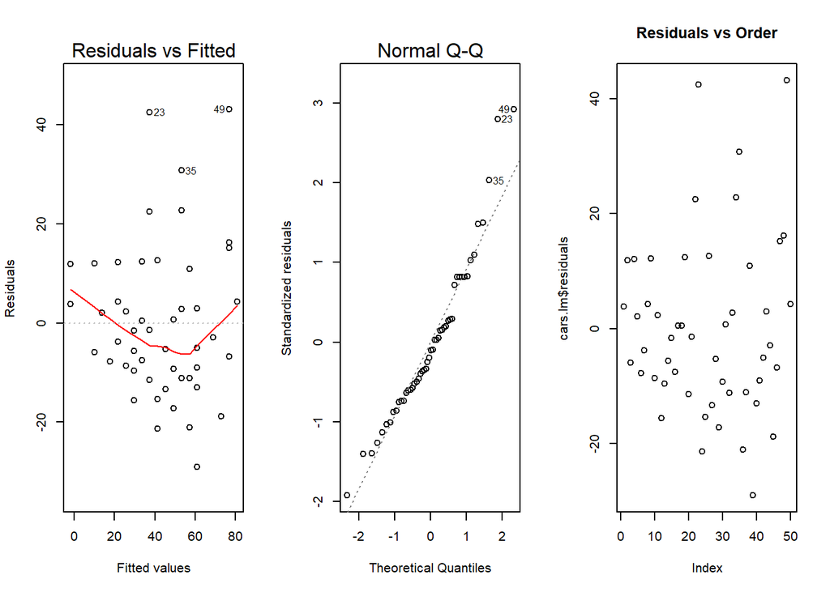

```r
#View(cars)

# Check Assumptions
par(mfrow=c(1,3))
plot(cars.lm, which=1:2)
plot(cars.lm$residuals, main = "Residuals vs Order")
```

```r
# plot(cars.lm, which = 1)
# qqPlot(cars.lm$residuals, main = "Q-Q Plot of Residuals", id = FALSE)

# Observation 23 speed 14 dist 80

80 - (-17.5791 + 3.9324*14)
```

```
## [1] 42.5255
```

#### Question 14 {done}

```r
airq.lm <- lm(Ozone ~ Temp, data=airquality)
summary(airq.lm) #0.4877
```

```
##
## Call:
## lm(formula = Ozone ~ Temp, data = airquality)
##
## Residuals:
##     Min      1Q  Median      3Q     Max
## -40.729 -17.409  -0.587  11.306 118.271
##
## Coefficients:
##              Estimate Std. Error t value Pr(>|t|)
## (Intercept) -146.9955    18.2872  -8.038 9.37e-13 ***
## Temp           2.4287     0.2331  10.418  < 2e-16 ***
## ---
## Signif. codes:  0 '***' 0.001 '**' 0.01 '*' 0.05 '.' 0.1 ' ' 1
##
## Residual standard error: 23.71 on 114 degrees of freedom
##   (37 observations deleted due to missingness)
## Multiple R-squared:  0.4877, Adjusted R-squared:  0.4832
## F-statistic: 108.5 on 1 and 114 DF,  p-value: < 2.2e-16
```

```r
airq.lm.log <- lm(log(Ozone) ~ Temp, data=airquality)
summary(airq.lm.log) # 0.5473
```

```
##
## Call:
## lm(formula = log(Ozone) ~ Temp, data = airquality)
##
## Residuals:
##      Min       1Q   Median       3Q      Max
## -2.14469 -0.33095  0.02961  0.36507  1.49421
##
## Coefficients:
##             Estimate Std. Error t value Pr(>|t|)
## (Intercept) -1.83797    0.45100  -4.075 8.53e-05 ***
## Temp         0.06750    0.00575  11.741  < 2e-16 ***
## ---
## Signif. codes:  0 '***' 0.001 '**' 0.01 '*' 0.05 '.' 0.1 ' ' 1
##
## Residual standard error: 0.5848 on 114 degrees of freedom
##   (37 observations deleted due to missingness)
## Multiple R-squared:  0.5473, Adjusted R-squared:  0.5434
## F-statistic: 137.8 on 1 and 114 DF,  p-value: < 2.2e-16
```

```r
airq.lm.sqrt <- lm(sqrt(Ozone) ~ Temp, data=airquality)
summary(airq.lm.sqrt) # 0.5527
```

```
##
## Call:
## lm(formula = sqrt(Ozone) ~ Temp, data = airquality)
##
## Residuals:
##     Min      1Q  Median      3Q     Max
## -3.7826 -1.2572  0.0857  1.0659  6.3426
##
## Coefficients:
##             Estimate Std. Error t value Pr(>|t|)
## (Intercept) -8.81129    1.25892  -6.999 1.89e-10 ***
## Temp         0.19050    0.01605  11.869  < 2e-16 ***
## ---
## Signif. codes:  0 '***' 0.001 '**' 0.01 '*' 0.05 '.' 0.1 ' ' 1
##
## Residual standard error: 1.633 on 114 degrees of freedom
##   (37 observations deleted due to missingness)
## Multiple R-squared:  0.5527, Adjusted R-squared:  0.5488
## F-statistic: 140.9 on 1 and 114 DF,  p-value: < 2.2e-16
```

```r
airq.lm.1 <- lm((Ozone^-1) ~ Temp, data=airquality)
summary(airq.lm.1) #0.1682
```

```
##
## Call:
## lm(formula = (Ozone^-1) ~ Temp, data = airquality)
##
## Residuals:
##      Min       1Q   Median       3Q      Max
## -0.09156 -0.02775 -0.00577  0.01101  0.86881
##
## Coefficients:
##               Estimate Std. Error t value Pr(>|t|)
## (Intercept)  0.3782920  0.0684228   5.529 2.07e-07 ***
## Temp        -0.0041882  0.0008723  -4.801 4.83e-06 ***
## ---
## Signif. codes:  0 '***' 0.001 '**' 0.01 '*' 0.05 '.' 0.1 ' ' 1
##
## Residual standard error: 0.08873 on 114 degrees of freedom
##   (37 observations deleted due to missingness)
## Multiple R-squared:  0.1682, Adjusted R-squared:  0.1609
## F-statistic: 23.05 on 1 and 114 DF,  p-value: 4.825e-06
```

#### Question 15 {done}

```r
#?ChickWeight
#View(ChickWeight)
ChickWeight.lm <- lm(weight ~ Time, data = ChickWeight)
```

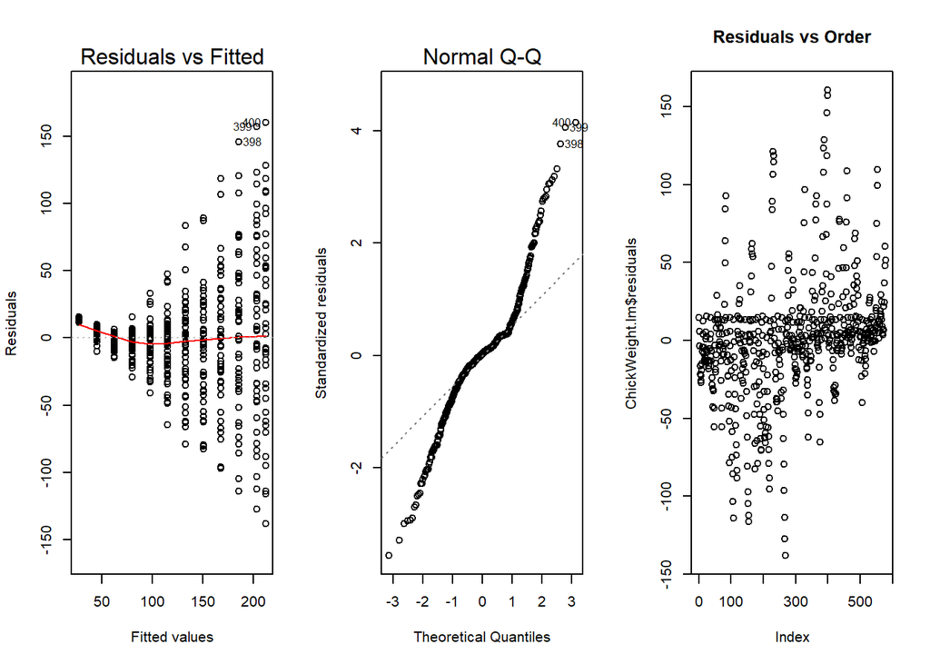

```r
# Check Assumptions
par(mfrow=c(1,3))
plot(ChickWeight.lm, which=1:2)
plot(ChickWeight.lm$residuals, main = "Residuals vs Order")
```

```r
# plot(ChickWeight.lm, which = 1)
# qqPlot(ChickWeight.lm$residuals, main = "Q-Q Plot of Residuals", id = FALS
```

Constant variance is obviously violated. Normal distributation is violated. Error terms may not be independent.

#### Question 16 {done}

## Question 17 {HELP/WRONG}

I’m not sure.

## Question 18 {done}

```r
sqrt(1.9/22) # 0.2938769
```

```
## [1] 0.2938769
```

```r
sqrt(77.3/22) # 1.87447
```

```
## [1] 1.87447
```

```r
sqrt(38.9/22) # 1.32973
```

```
## [1] 1.32973
```

```r
sqrt(25.2/22) # 1.070259
```

```
## [1] 1.070259
```

## Question 19 {done/WRONG}

```r
#T-stat math formula: (Estimate (b_0 or b_1) - hypothesis number)/std.Error_{b_0 or b_1}

(389.075 - 0)/374.182 # Testing the value of y
```

```
## [1] 1.039801
```

```r
(-6.171 - 0)/51.379 # Testing first x value
```

```
## [1] -0.1201074
```

```r
(-109.736 - 0)/374.404 # My question
```

```
## [1] -0.2930952
```

```r
pt(-abs((-109.736 - 0)/374.404), 27)*2 # Subtract 3 parameters from this
```

```
## [1] 0.7716903
```

## Question 20 {done}

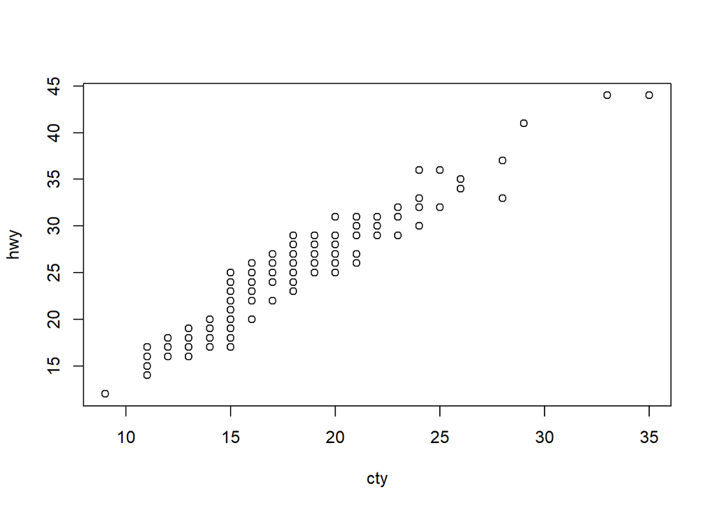

```r
# ?mpg
# View(mpg)

plot(hwy ~ cty, data = mpg)
```

```r
mpg.lm <- lm(hwy ~ cty, data=mpg)
summary(mpg.lm)
```

```
##
## Call:
## lm(formula = hwy ~ cty, data = mpg)
##
## Residuals:
##     Min      1Q  Median      3Q     Max
## -5.3408 -1.2790  0.0214  1.0338  4.0461
##
## Coefficients:
##             Estimate Std. Error t value Pr(>|t|)
## (Intercept)  0.89204    0.46895   1.902   0.0584 .
## cty          1.33746    0.02697  49.585   <2e-16 ***
## ---
## Signif. codes:  0 '***' 0.001 '**' 0.01 '*' 0.05 '.' 0.1 ' ' 1
##
## Residual standard error: 1.752 on 232 degrees of freedom
## Multiple R-squared:  0.9138, Adjusted R-squared:  0.9134
## F-statistic:  2459 on 1 and 232 DF,  p-value: < 2.2e-16
```

## Question 21 {done}

Use the Orange dataset in R to perform a linear regression of the circumference (y) of an orange tree according to the age of the tree (x).

Which regression assumption is not satisfied for this regression?

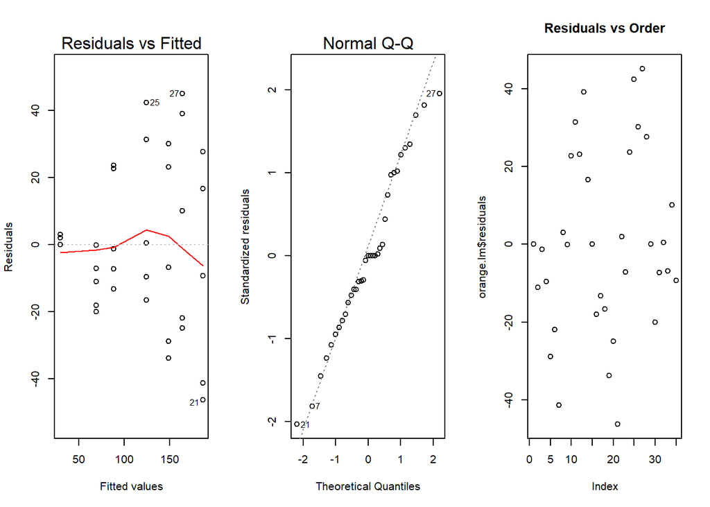

```r
orange.lm <- lm(circumference ~ age, data = Orange)
# ?Orange
# Check Assumptions
par(mfrow=c(1,3))
plot(orange.lm, which=1:2)
plot(orange.lm$residuals, main = "Residuals vs Order")
```

```r
# plot(orange.lm, which = 1)
# qqPlot(orange.lm$residuals, main = "Q-Q Plot of Residuals", id = FALS
```

## Question 22 {done}

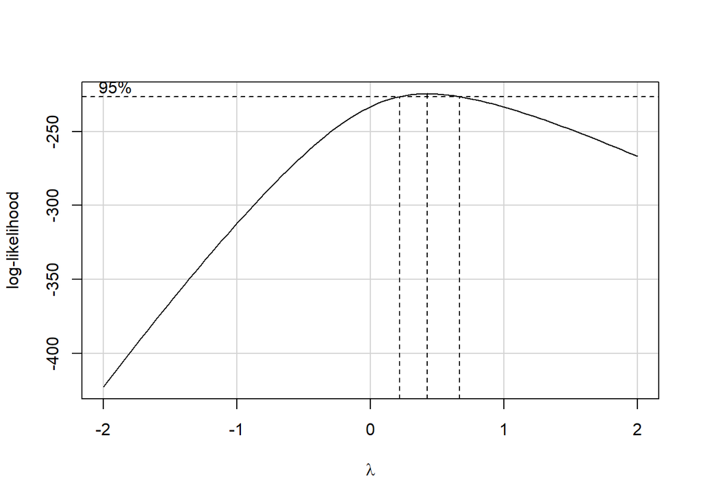

```r
cars.lm <- lm(dist ~ speed, data = cars)
cars.lm.co <- cars.lm$coefficients
boxCox(cars.lm)
```

```r
cars.lm.t <- lm(sqrt(dist) ~ speed, data = cars)
cars.lm.t.co <- cars.lm.t$coefficients
```

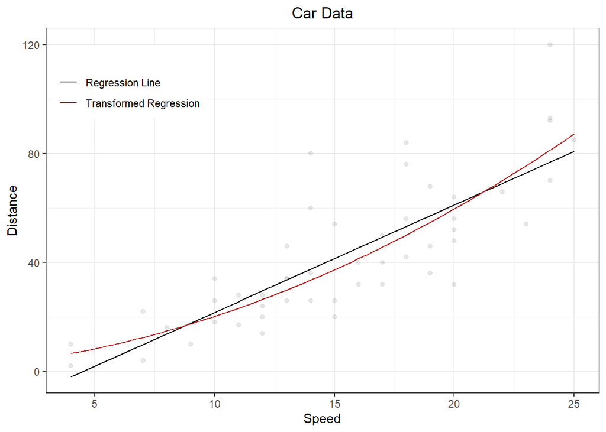

```r
cars %>%
  ggplot(aes(y = dist, x = speed)) +
  geom_point(alpha = .09) +
  stat_function(fun = function(x)cars.lm.co[1] + cars.lm.co[2]*x,
                aes(color = "a")) +
  stat_function(fun = function(x){(cars.lm.t.co[1] + cars.lm.t.co[2]*x)^2},
                aes(color = "b")) +
  labs(title = "Car Data",
       x = "Speed",
       y = "Distance") +
  theme_bw() +
  theme(plot.title = element_text(hjust = 0.5),
        plot.subtitle = element_text(hjust = 0.5),
        legend.position = c(0.15, .85)) +
  scale_color_manual("",
                     values = c("black", "firebrick"),
                     labels = c("Regression Line", "Transformed Regression"))
```

#### Question 23 {done}

describe SSR

## Question 24 {done}

```r
Loblolly.lm <- lm(height ~ age, data = Loblolly)
Loblolly.lm.co <- Loblolly.lm$coefficients
```

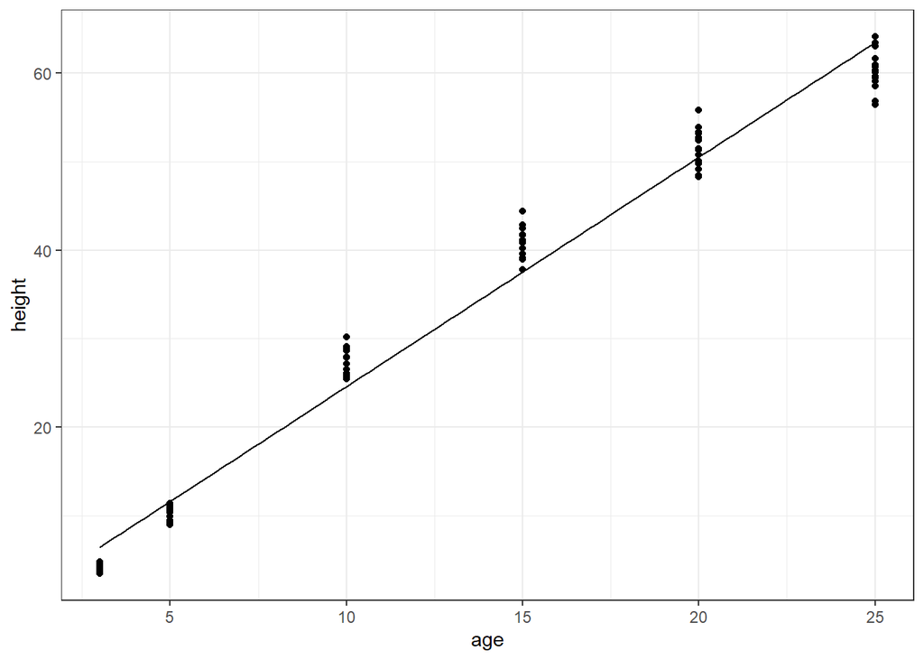

```r
Loblolly %>%
  ggplot(aes(y = height, x = age)) +
  geom_point() +
  stat_function(fun = function(x)Loblolly.lm.co[1] + Loblolly.lm.co[2]*x) +
  theme_bw()
```

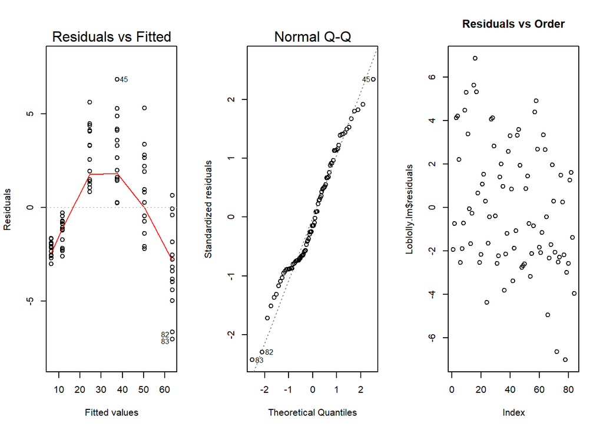

```r
# Check Assumptions
par(mfrow=c(1,3))
plot(Loblolly.lm, which=1:2)
plot(Loblolly.lm$residuals, main = "Residuals vs Order")
```

```r
# plot(Loblolly.lm, which = 1)
# qqPlot(Loblolly.lm$residuals, main = "Q-Q Plot of Residuals", id = FALS
```

## Question 25 {done/WRONG}

I’m going with X2 X3 because it appears that no matter the angle I’ll have more data points further away from the line while the others seem to have a heavier set of data towards the line, at least in the beginning or in general. Meaning that there are more data points clumped towards the line and not towards the outer bounds of the graph.